# Topic 6: Topic Analysis

```r
library(here)
library(pdftools)
library(quanteda)
library(tm)
library(topicmodels)
library(ldatuning)
library(tidyverse)
library(tidytext)
library(reshape2)
```

Load the data

```r
##Topic 6 .Rmd here:https://raw.githubusercontent.com/MaRo406/EDS_231-text-sentiment/main/topic_6.Rmd
#grab data here:
comments_df<-read_csv("https://raw.githubusercontent.com/MaRo406/EDS_231-text-sentiment/main/dat/comments_df.csv")
#comments_df <- read_csv(here("dat", "comments_df.csv")) #if reading from local
```

Now we’ll build and clean the corpus

```r
epa_corp <- corpus(x = comments_df, text_field = "text")
epa_corp.stats <- summary(epa_corp)
head(epa_corp.stats, n = 25)
```

```
##      Text Types Tokens Sentences
## 1   text1  1196   3973       178
## 2   text2   830   2509       111
## 3   text3   279    571        31
## 4   text4  1745   6904       251
## 5   text5   581   1534        49
## 6   text6   469   1187        53
## 7   text7   424    903        38
## 8   text8  3622  22270       655
## 9   text9   373    717        25
## 10 text10   404    971        42
## 11 text11   710   2190        77
## 12 text12   636   1896        82
## 13 text13   146    206         3
## 14 text14  1124   3197        86
```

[output cut: 37 more lines]

```r
# create tokens obj, remove punct and numeral and stop words
toks <- tokens(epa_corp, remove_punct = TRUE, remove_numbers = TRUE)

# I added some project-specific stop words here
add_stops <- c(stopwords("en"),"environmental", "justice", "ej", "epa", "public", "comment")
toks1 <- tokens_select(toks, pattern = add_stops, selection = "remove")
```

And now convert to a document-feature matrix

```r
# convert to document feature matrix
dfm_comm<- dfm(toks1, tolower = TRUE)
# reduce words to base word
dfm <- dfm_wordstem(dfm_comm)
# remove terms only appearing in one doc (min_termfreq = 10)
dfm <- dfm_trim(dfm, min_docfreq = 2)

print(head(dfm)) # each comment is a row, each col is a term
```

```
## Document-feature matrix of: 6 documents, 2,781 features (82.75% sparse) and 1 docvar.
##        features
## docs    charl lee deputi associ assist administr usepa offic 2201-a
##   text1     1   2      1      1      6         6     1     7      1
##   text2     1   1      1      4      3         1     0     5      0
##   text3     0   0      0      0      1         0     0     2      0
##   text4     0   0      0      0      1         9     0     1      0
##   text5     4   5      1      1      1         1     0     1      1
##   text6     1   1      1      3      1         3     0     4      0
##        features
## docs    pennsylvania
##   text1            1
##   text2            0
##   text3            0
##   text4            0
##   text5            1
##   text6            0
## [ reached max_nfeat ... 2,771 more features ]
```

```r
# remove rows (docs) with all zeros (these 0's are present bc we removed stop words)
sel_idx <- slam::row_sums(dfm) > 0
dfm <- dfm[sel_idx, ]
#comments_df <- dfm[sel_idx, ]
```

We somehow have to come up with a value for k,the number of latent topics present in the data. How do we do this? There are multiple methods. Let’s use what we already know about the data to inform a prediction. The EPA has 9 priority areas: Rulemaking, Permitting, Compliance and Enforcement, Science, States and Local Governments, Federal Agencies, Community-based Work, Tribes and Indigenous People, National Measures. Maybe the comments correspond to those areas?

```r
k <- 9

# feed in the DFM and the num of topics to look for and number of iterations, this function estimates the 2 matrices
topicModel_k9 <- LDA(dfm, k, method="Gibbs", control=list(iter = 500, verbose = 25))
```

```
## K = 9; V = 2781; M = 77
## Sampling 500 iterations!
## Iteration 25 ...
## Iteration 50 ...
## Iteration 75 ...
## Iteration 100 ...
## Iteration 125 ...
## Iteration 150 ...
## Iteration 175 ...
## Iteration 200 ...
## Iteration 225 ...
## Iteration 250 ...
## Iteration 275 ...
## Iteration 300 ...
## Iteration 325 ...
## Iteration 350 ...
## Iteration 375 ...
## Iteration 400 ...
## Iteration 425 ...
## Iteration 450 ...
## Iteration 475 ...
## Iteration 500 ...
## Gibbs sampling completed!
```

```r
#nTerms(dfm_comm)

tmResult <- posterior(topicModel_k9)
tmResult
```

[output not shown]

[output cut: 4864 more lines]

```r
attributes(tmResult)
```

```
## $names
## [1] "terms"  "topics"
```

```r
#ncol(tmResult) # does not run

#nTerms(dfm_comm)
beta <- tmResult$terms   # get beta from results
dim(beta)                # K distributions over nTerms(DTM) terms# lengthOfVocab
```

```
## [1]    9 2781
```

```r
terms(topicModel_k9, 10)
```

```
##       Topic 1   Topic 2     Topic 3    Topic 4     Topic 5         Topic 6
##  [1,] "prison"  "communiti" "state"    "state"     "water"         "communiti"
##  [2,] "peopl"   "pollut"    "permit"   "program"   "work"          "framework"
##  [3,] "project" "impact"    "consid"   "epa"       "juli"          "agenc"
##  [4,] "citi"    "state"     "comment"  "requir"    "site"          "draft"
##  [5,] "health"  "health"    "opportun" "feder"     "can"           "effort"
##  [6,] "park"    "rule"      "air"      "regul"     "often"         "develop"
##  [7,] "includ"  "air"       "use"      "will"      "energi"        "agenda"
##  [8,] "center"  "popul"     "organ"    "process"   "communiti"     "action"
##  [9,] "law"     "also"      "feder"    "implement" "clean"         "tool"
## [10,] "green"   "avail"     "meet"     "import"    "infrastructur" "support"
##       Topic 7     Topic 8     Topic 9
##  [1,] "communiti" "communiti" "agenc"
##  [2,] "enforc"    "local"     "right"
##  [3,] "monitor"   "plan"      "civil"
##  [4,] "action"    "action"    "titl"
##  [5,] "comment"   "use"       "vi"
##  [6,] "air"       "strategi"  "plan"
##  [7,] "complianc" "agenda"    "communiti"
##  [8,] "includ"    "govern"    "issu"
##  [9,] "data"      "comment"   "polici"
## [10,] "assess"    "particip"  "act"
```

Some of those topics seem related to the cross-cutting and additional topics identified in the EPA’s response to the public comments:

1. Title VI of the Civil Rights Act of 1964

2.[EJSCREEN](https://www.epa.gov/ejscreen/download-ejscreen-data)

3. climate change, climate adaptation and promoting greenhouse gas reductions co-benefits

4. overburdened communities and other stakeholders to meaningfully, effectively, and transparently participate in aspects of EJ 2020, as well as other agency processes

5. utilize multiple Federal Advisory Committees to better obtain outside environmental justice perspectives

6. environmental justice and area-specific training to EPA staff

7. air quality issues in overburdened communities

So we could guess that there might be a 16 topics (9 priority + 7 additional). Or we could calculate some metrics from the data. (what initial value of k gives us the best model)

```r
# fit the model by running a series of models, starting with 2 topics and ranging to 20 topics
result <- FindTopicsNumber(
  dfm,
  topics = seq(from = 2, to = 20, by = 1),
  metrics = c("CaoJuan2009",  "Deveaud2014"),
  method = "Gibbs",
  control = list(seed = 77),
  verbose = TRUE
)
```

```
## fit models... done.
## calculate metrics:
##   CaoJuan2009... done.
##   Deveaud2014... done.
```

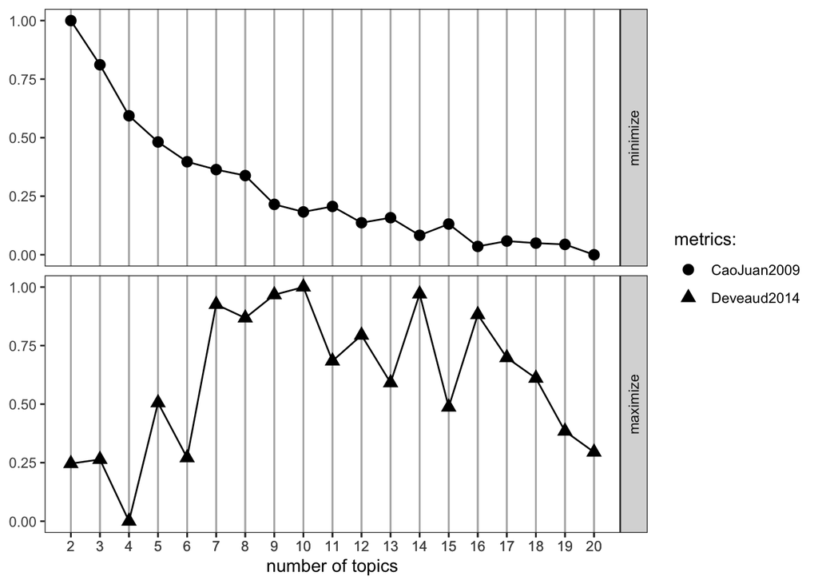

```r
FindTopicsNumber_plot(result)
```